# Análisis de datos para predictor académico UA

Facundo Rivas y Brian Biale

14/5/2019

# Introducción

### Obtención de los datos

Para la realización de este reporte fueron proporcionados tres archivos *.xlsx*, los cuales contienen ingresantes de los años 2018 y 2019 de la facultad de ingeniería de la Universidad Austral. Estos datos pasaron primeramente por una etapa de *“Data Curation”* o *“Curación de Datos”*, para mejorar su calidad. A continuación se muestra una preview de como quedaron ordenados los datos con sus respectivas variables:

| Name | Gender | Cohort | Entry | Math | R.Math | Physics | R.Physics | Entry Average | HS Average | School | Year |
| --- | --- | --- | --- | --- | --- | --- | --- | --- | --- | --- | --- |
| Estay Herreros Losio | M | 2018 | Ingreso Febrero | 4 | NA | 3 | 4 | 4 | NA | Sworn | 2018 |
| Pantaleone Marin Tomas | M | 2018 | Cuatrimestral | 7 | NA | 7 | NA | 7 | NA | San Jose | 2018 |
| Braian Mateo Sol | M | 2018 | Ingreso Febrero | 4 | NA | 6 | NA | 5 | NA | San Jose | 2018 |
| Berton Mato Juan | M | 2018 | Ingreso Febrero | 4 | NA | 4 | NA | 4 | NA | Santa Soledad Torres Acosta | 2018 |
| Luciana Lautaro Felix | F | 2018 | Ingreso Directo | NA | NA | NA | NA | NaN | NA | Northlands | 2018 |
| Santiago Federico Rico | M | 2018 | Pase Universitario | NA | NA | NA | NA | NaN | NA | BedeÂ´s Grammar School | 2018 |
| Ivan Benjamín Marcos | M | 2018 | Ingreso Febrero | 10 | NA | 9 | NA | 10 | NA | Cardenal Pironio | 2018 |
| Emiliani Tomás Ivan | M | 2018 | Ingreso Febrero | 6 | NA | 9 | NA | 8 | NA | Lord Byron School (Peru) | 2018 |
| Fabrizio Gonzalez Martinez | M | 2018 | Ingreso Directo | NA | NA | NA | NA | NaN | NA | Los Molinos | 2018 |
| Maximiliano Abalo Alejandro | M | 2018 | Pase Universitario | NA | NA | NA | NA | NaN | NA | Colegio Peruano Britanico (Peru) | 2018 |

# Análisis

### Calidad de los datos

Como se puede ver hay 12 variables que caracterizan a cada uno de los elementos pertenecientes al conjunto de datos. Luego del proceso de *“Data Curation”*, hay muchas observaciones de las variables que no estan completas. Esto se debe a que, o bien fueron añadidas dichas variables al conjunto original de datos, o bien a que los datos fueron proporcionados ya de esta manera, lo cual afecta a la calidad que tiene la variable. En la siguiente tabla se muestran las variables con sus respectivas calidades (Cantidad de *NA* en cada variable, sobre el total de elementos que conforman el conjunto de datos):

|  | Porcentaje |
| --- | --- |
| Name | 100 |
| Gender | 100 |
| Cohort | 100 |
| Entry | 100 |
| Math | 82 |
| R.Math | 17 |
| Physics | 81 |
| R.Physics | 9 |
| Entry Average | 84 |
| HS Average | 23 |
| School | 100 |
| Year | 100 |

### Análisis variable a variable

Una vez curados los datos, se hace un análisis “variable a variable” para extraer información de las mismas.

#### Género de los ingresantes

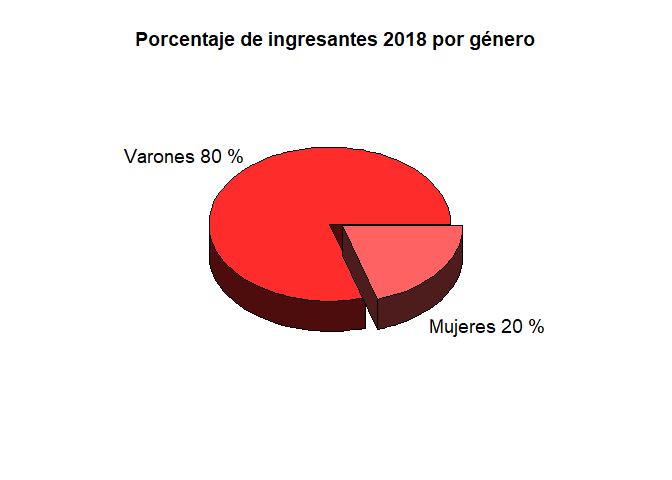

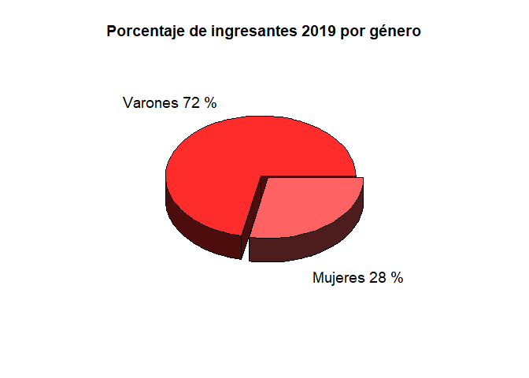

Como puede notarse en los gráficos que el porcentaje de mujeres con respecto al de varones es mayor en el año 2019 que en el 2018.

#### Tipos de ingreso

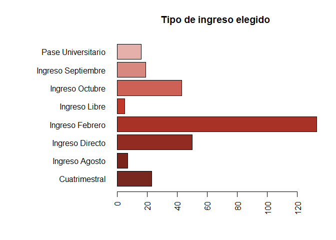

#### Colegios de procedencia

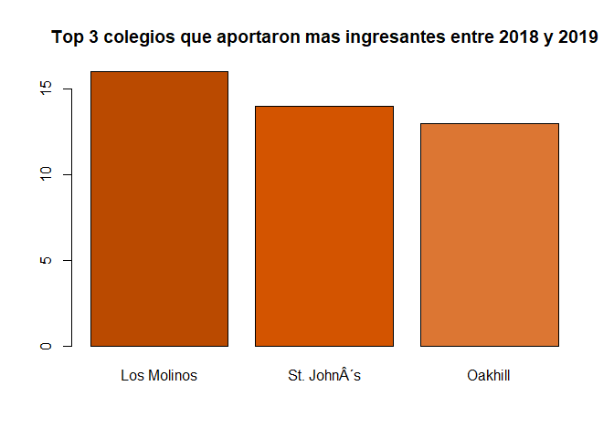

El eje vertical del gráfico representa la cantidad de ingresantes que proporciona cada colegio y el eje horizontal contiene los nombres de los colegios. “Los Molinos”, el colegio que más aportó ingresantes es de la misma zona que la Universidad Austral.

#### Notas del examen de Matemática

Se analizan el promedio de todas las notas y el porcentaje de ingresantes que aprobaron el examen en primer instancia, en los años 2018 y 2019.

**2018:**

| Promedio | Aprobados |
| --- | --- |
| 6 | 63 % |

**2019:**

| Promedio | Aprobados |
| --- | --- |
| 6 | 59 % |

El promedio de nota de los exámenes se mantuvo igual pero el porcentaje de aprobados del año 2019 es menor.

#### Notas del examen de Física

Se analizan el promedio de todas las notas y el porcentaje de ingresantes que aprobaron el examen en primer instancia, en los años 2018 y 2019.

**2018:**

| Promedio | Aprobados |
| --- | --- |
| 8 | 92 % |

**2019:**

| Promedio | Aprobados |
| --- | --- |
| 7 | 74 % |

El promedio de nota de los exámenes bajó y al igual que el porcentaje de aprobados.

**Se puede notar que en ambas materias el porcentaje de aprobados del año 2019 es menor que el de 2018**

#### Promedio de ingreso

Se analizan los datos de promedio de ingreso observando el porcentaje de ingresantes que obtuvo una puntuación mayor a 7.

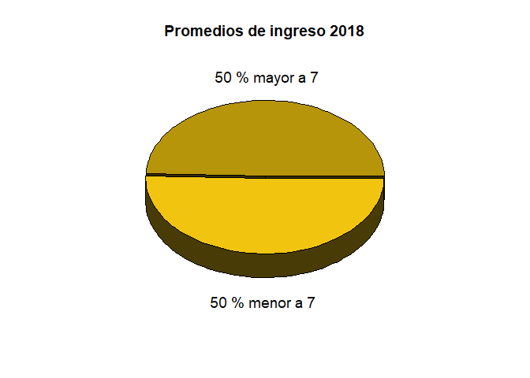

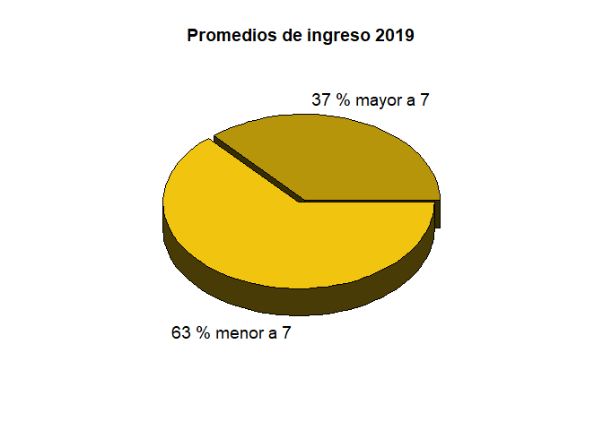

**Observese que el porcentaje de ingresantes que obtuvieron un promedio mayor a 7 en 2019 es más de un 10% menor que en 2018.**

#### Promedio de secundaria

Analizamos los datos de promedio de secundaria y obtenemos un top 5.

| Name | HS Average |
| --- | --- |
| Lucas Susnisky Joaquin | 9.60 |
| Delfina Arias Tomas | 9.45 |
| Katia Maximiliano Matias | 9.41 |
| Fernandez Pedro Olivera | 9.34 |
| Santiago Pianetti Martinez | 9.20 |

La primer columna representando el nombre y la segunda representando el promedio de secundaria.

#### Recuperatorios

Para las columnas de recuperatorios (Matemática y Física) se analizaron los datos obteniendo un porcentaje de ingresantes que tuvieron que rendir recuperatorio para cada año.

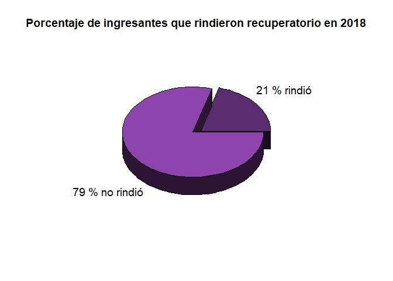

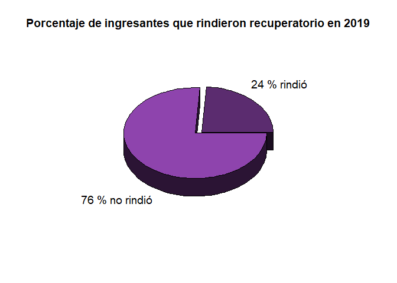

**Los porcentajes para ambos años son muy similares.**

# Interpretación

Luego de analizar los datos variable a variable, se hace una interpretación de dichos análisis cruzando datos con el fin de obtener más información de las conclusiones a las que se llega.

#### Media de los promedios de ingreso segun género

**2018:**

| Gender | Mean |
| --- | --- |
| Varones | 7.01 |
| Mujeres | 7.41 |

Las mujeres obtuvieron un promedio de ingreso 0.40 puntos mayor al de los varones.

**2019:**

| Gender | Mean |
| --- | --- |
| Varones | 6.46 |
| Mujeres | 6.55 |

Las mujeres obtuvieron un promedio de ingreso 0.09 puntos mayor al de los varones.

**La diferencia de promedios de ingreso entre varones y mujeres fue mas baja en el último año.**